# Getting started with `mcbarycenter` package

James Peng, Florian Stijven, Linbo Wang, Peter Gilbert

```r
library(mcbarycenter)
library(dplyr)
```

# Introduction

The `mcbarycenter` package implements a method for estimating the quantile function of the Wasserstein barycenter using the marginal-constructed barycenter (MCB) procedure. Briefly, the estimator can be used in sparse sampling settings, in which each distribution is observed only through a potentially small i.i.d. sample. The estimator works by first estimating a series of binomial mixing distributions using a beta parametric specification, a spline parametric specification, or the NPMLE. It then combines those mixing distributions to estimate the Wasserstein barycenter.

For more details, please see [Peng, Stijven et al. (arXiv, 2026)](https://arxiv.org/abs/2606.10096).

The `mcbarycenter` package estimates the quantile function of the Wasserstein barycenter using either the empirical barycenter or the MCB estimator. In addition, the package provides tools for calculating quantile differences, graphing results, and carrying out hypothesis tests to compare barycenters across groups of distributions.

Some functionality depends on external packages. In particular, `REBayes` and `Rmosek` can be used to make the NPMLE workflow run faster. To implement the spline mixing distribution estimator, we used code from `deconvolveR`, but rewrote the relevant function to make it faster for this package’s use case.

The examples below use the bundled `sparse_dist_data` data set.

```r
data("sparse_dist_data")
head(sparse_dist_data)
```

```
#>   group id value
#> 1     1  1  0.20
#> 2     1  1  0.20
#> 3     1  1  0.20
#> 4     1  2 -0.35
#> 5     1  2 -0.12
#> 6     1  2  0.08
```

Note that the data set must be in long format, with one column specifying the ids of the distributions and another column specifying the i.i.d. samples from those distributions.

# Graphing individual empirical quantiles

To visualize the empirical quantile curve for each individual distribution, we can use `graph_individual_quantiles()`. This helper starts from a raw data frame in long format, computes empirical quantiles separately for each `id`, and then plots the resulting curves on a common quantile grid.

When `interactive = TRUE` (the default), the function returns an interactive `plotly` widget. The curves are visible by default, and clicking a line highlights the selected individual. Double-clicking resets the plot. Because the graph can become crowded when there are many ids, the example below focuses on the first 10 individuals. In the bundled sample data, ids `1`, `2`, and `3` are intentionally shaped to illustrate a homogeneous three-sample curve, a right-tailed curve, and a high-variability curve.

```r
first_10_df <- sparse_dist_data %>%
  filter(id %in% 1:10)

graph_individual_quantiles(first_10_df,
                           id_col = "id",
                           val_col = "value")
```

[interactive chart not shown]

If a static figure is preferred, set `interactive = FALSE` to return a ggplot object instead.

For larger datasets, you can also cap the plotted curve resolution with `max_points`. This keeps an approximately evenly spaced subset of the quantile grid before computing the displayed curves, which can make the interactive `plotly` widget load much faster.

# Estimating the Wasserstein barycenter quantile function

## Empirical Wasserstein barycenter

The `empbary()` function computes empirical quantiles for each subject and then averages those quantiles pointwise within each group.

Arguments:

- `df`: the input data frame.
- `id_col`: the column identifying subjects or groups.
- `val_col`: the column containing the numeric observations.
- `weight_col`: an optional column containing group weights; if omitted, the empirical barycenter is unweighted.
- `alpha_grid`: the grid of quantile levels to estimate.
- `quantile_type`: the `type` argument passed to `stats::quantile()`.

Returns:

- An `empbary_result` object containing the estimated quantile curve in `res`, an estimated covariance matrix in `cov`, and the standardized input data in `data`.
- This objected can be plotted with the function `graph_quantiles()`.

Example:

```r
sample_grp1 <- subset(sparse_dist_data, group == 1)
sample_grp2 <- subset(sparse_dist_data, group == 2)

emp_res_grp1 <- empbary(
  df = sample_grp1,
  id_col = "id",
  val_col = "value"
)

emp_res_grp2 <- empbary(
  df = sample_grp2,
  id_col = "id",
  val_col = "value"
)

head(emp_res_grp1$res)
```

```
#>   quantile  estimate         se     ci_lo     ci_hi
#> 1     0.01 -1.233814 0.05900223 -1.349456 -1.118172
#> 2     0.02 -1.233814 0.05900223 -1.349456 -1.118172
#> 3     0.03 -1.233814 0.05900223 -1.349456 -1.118172
#> 4     0.04 -1.233814 0.05900223 -1.349456 -1.118172
#> 5     0.05 -1.233814 0.05900223 -1.349456 -1.118172
#> 6     0.06 -1.233814 0.05900223 -1.349456 -1.118172
```

```r
head(emp_res_grp2$res)
```

```
#>   quantile  estimate         se     ci_lo      ci_hi
#> 1     0.01 -1.050571 0.05949284 -1.167175 -0.9339675
#> 2     0.02 -1.050571 0.05949284 -1.167175 -0.9339675
#> 3     0.03 -1.050571 0.05949284 -1.167175 -0.9339675
#> 4     0.04 -1.050571 0.05949284 -1.167175 -0.9339675
#> 5     0.05 -1.050571 0.05949284 -1.167175 -0.9339675
#> 6     0.06 -1.050571 0.05949284 -1.167175 -0.9339675
```

## Marginal-constructed barycenter

Arguments:

- `df`, `id_val`, `val_col`: same arguments as in `empbary()` function.
- `method`: the mixture estimation method; options include `"spline"`, `"npmle"`, `"raw"`, and `"beta"`.
- `x_grid`: the threshold grid to use when `cutpoints` is not supplied.
- `cutpoints`: the number of evenly spaced grid points constructed from the observed data range; either `cutpoints` or `x_grid` must be supplied.
- `bootstrap_samples`: the number of bootstrap resamples used for uncertainty estimation.
- `alpha_grid`: the grid of quantile levels to estimate.
- `use_midpoint`: whether to use interval midpoints when constructing the quantile distribution.
- `estimate_endpoints`: whether to estimate the endpoint support regions.
- `use_isotonic_dist`: whether to enforce monotonicity on the estimated distribution of quantiles before converting them to quantile distributions.
- `use_isotonic_output`: whether to enforce monotonicity on the final estimated quantile curve and confidence bounds.
- `weight_col`: an optional column containing id-level weights.
- `progress`: whether to display a bootstrap progress bar.
- `ci_level`: the confidence level used for reported intervals.
- `...`: additional arguments passed to the mixture estimation routine.

Returns:

- An `mcbary_result` object containing the estimated quantile curve and uncertainty summaries in `res`, the bootstrap covariance matrix in `cov`, the estimated mixing distributions in `mixtures`, the chosen estimation method in `method`, and the standardized input data in `data`.

```r
mcb_res_grp1 <- mcbary(
  df = sample_grp1,
  id_col = "id",
  val_col = "value",
  method = "beta",
  cutpoints = 100,
  use_midpoint = TRUE,
  estimate_endpoints = TRUE,
  bootstrap_samples = 20,
  progress = FALSE
)

mcb_res_grp2 <- mcbary(
  df = sample_grp2,
  id_col = "id",
  val_col = "value",
  method = "beta",
  cutpoints = 100,
  use_midpoint = TRUE,
  estimate_endpoints = TRUE,
  bootstrap_samples = 20,
  progress = FALSE
)
head(mcb_res_grp1$res)
```

```
#>   quantile  estimate estimate_bs         se     ci_lo     ci_hi pct_ci_lo
#> 1     0.01 -2.425729   -2.566993 0.23530877 -2.886926 -1.964532 -2.916458
#> 2     0.02 -2.118623   -2.090118 0.14009682 -2.393208 -1.844039 -2.256057
#> 3     0.03 -1.959824   -1.936493 0.11691260 -2.188968 -1.730679 -2.129681
#> 4     0.04 -1.836431   -1.815537 0.10428660 -2.040829 -1.632033 -2.026267
#> 5     0.05 -1.734236   -1.710055 0.08353099 -1.897954 -1.570518 -1.855093
#> 6     0.06 -1.645746   -1.628509 0.07753751 -1.797717 -1.493775 -1.746508
#>   pct_ci_hi
#> 1 -2.190160
#> 2 -1.841537
#> 3 -1.753633
#> 4 -1.673224
#> 5 -1.576489
#> 6 -1.486366
```

```r
head(mcb_res_grp2$res)
```

```
#>   quantile  estimate estimate_bs         se     ci_lo     ci_hi pct_ci_lo
#> 1     0.01 -2.101027   -2.245103 0.15543800 -2.405680 -1.796374 -2.482212
#> 2     0.02 -1.906815   -1.946228 0.11275230 -2.127806 -1.685825 -2.150284
#> 3     0.03 -1.765184   -1.784037 0.09247381 -1.946430 -1.583939 -1.948785
#> 4     0.04 -1.652430   -1.665424 0.09408066 -1.836825 -1.468035 -1.859512
#> 5     0.05 -1.558018   -1.558283 0.10129283 -1.756549 -1.359488 -1.788696
#> 6     0.06 -1.476152   -1.467169 0.08628206 -1.645262 -1.307043 -1.655781
#>   pct_ci_hi
#> 1 -2.006337
#> 2 -1.776381
#> 3 -1.629001
#> 4 -1.517107
#> 5 -1.410079
#> 6 -1.342722
```

# Graphing tools

The package includes helpers for plotting both the estimated barycenter quantiles and the intermediate mixing distributions.

The graph below displays the empirical barycenters and the MCB estimators for groups 1 and 2.

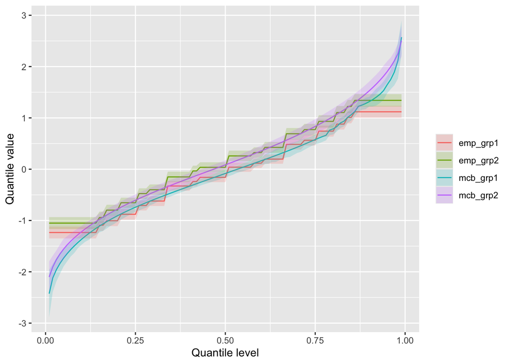

```r
graph_quantiles(
  emp_grp1 = emp_res_grp1,
  emp_grp2 = emp_res_grp2,
  mcb_grp1 = mcb_res_grp1,
  mcb_grp2 = mcb_res_grp2
)
```

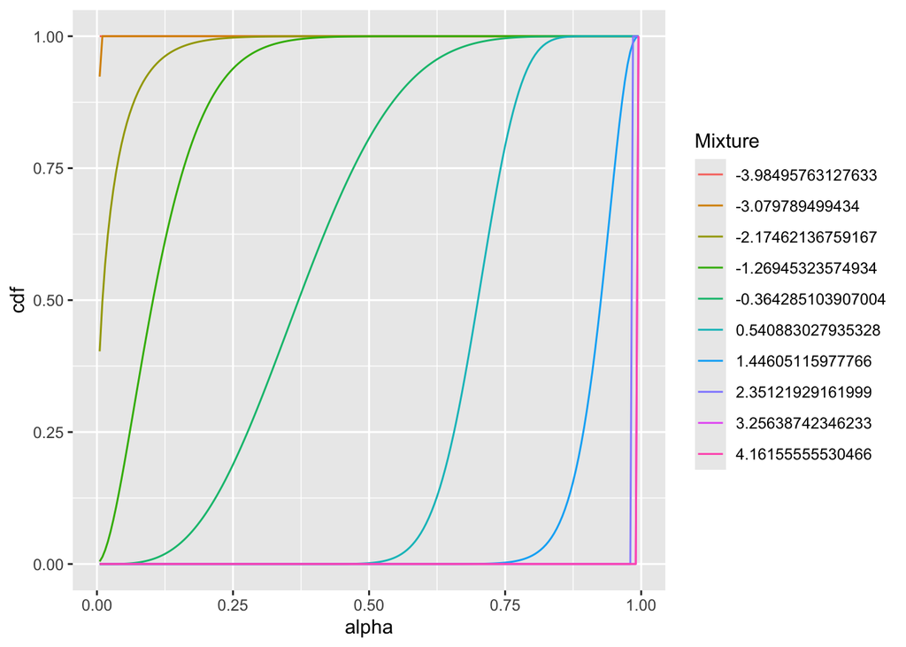

```r
graph_mixtures(mcb_res_grp1)
```

# Comparing Wasserstein barycenters

To compare barycenters between groups of observations, we can use the `quantile_diff()` function, which calculates the quantile differences between the two groups.

For example, we can compute the difference between the estimated MCB quantile functions for groups 1 and 2, and then graph the resulting quantile difference curve.

```r
quantile_diff_res <- quantile_diff(mcb_res_grp1, mcb_res_grp2)

head(quantile_diff_res)
```

```
#>   quantile   estimate        se      ci_lo      ci_hi
#> 1     0.01 -0.3247018 0.2820127 -0.8774366 0.22803302
#> 2     0.02 -0.2118083 0.1798338 -0.5642761 0.14065954
#> 3     0.03 -0.1946393 0.1490636 -0.4867987 0.09751999
#> 4     0.04 -0.1840011 0.1404524 -0.4592827 0.09128048
#> 5     0.05 -0.1762177 0.1312923 -0.4335458 0.08111046
#> 6     0.06 -0.1695939 0.1160028 -0.3969553 0.05776750
```

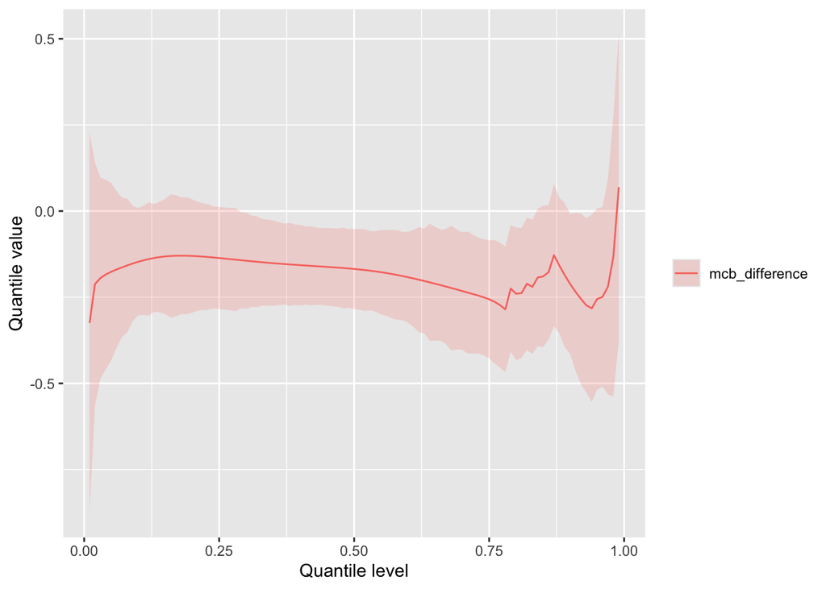

```r
graph_quantiles(mcb_difference = quantile_diff_res)
```

To compare barycenters across samples, we first estimate each barycenter on the same quantile grid and then apply `equalbary_test()`. Here we compare the two groups in `sparse_dist_data`.

```r
comparison <- equalbary_test(mcb_res_grp1, mcb_res_grp2, B = 1000, seed = 1)

comparison$sup_norm$pval
```

```
#> [1] 0.033
```

```r
comparison$int_sq_norm$pval
```

```
#> [1] 0
```

```r
comparison$hotelling$pval
```

```
#> [1] 0.06111304
```